# EDA Notebook

# Making units to integers

> Due to many rows of unit_sales having fractions of numbers, where the average unit price gets very high, we have decided to filter data to only include rows where unit_sales are integers

```r
sdf_filter <- sdf[sdf$UNIT_SALES %% 1 == 0,]
min(sdf$UNIT_SALES) # lowest is a fraction lower than 0
```

```
## [1] 0.04
```

```r
min(sdf_filter$UNIT_SALES) # lowest is 0
```

```
## [1] 1
```

# Geographical data

```r
market_data <- read_csv("zip_to_market_unit_mapping.csv")
consumer_demographics <- read_csv("demo_data.csv")
```

## join market key

```r
# Load necessary libraries
library(dplyr)

# Renaming the ZIP_CODE column in zip_to_market to match the Zip column in demo_data
market_data <- rename(market_data, Zip = ZIP_CODE)

# Join the datasets based on Zip code
joined_data <- left_join(consumer_demographics, market_data, by = "Zip")

# View the first few rows of the joined dataset
head(joined_data)
```

```
## # A tibble: 6 × 9
##   `Geography Name`     Zip City     State Segment  Crite…¹ Count Crite…² MARKE…³
##   <chr>              <dbl> <chr>    <chr> <chr>    <chr>   <dbl> <chr>     <dbl>
## 1 85281 Tempe, AZ    85281 Tempe    AZ    Househo… Income…  3628 HHs         913
## 2 85705 Tucson, AZ   85705 Tucson   AZ    Househo… Income…  3299 HHs         793
## 3 85364 Yuma, AZ     85364 Yuma     AZ    Househo… Income…  2852 HHs          44
## 4 85301 Glendale, AZ 85301 Glendale AZ    Househo… Income…  2425 HHs         949
## 5 85719 Tucson, AZ   85719 Tucson   AZ    Househo… Income…  2305 HHs         801
## 6 85716 Tucson, AZ   85716 Tucson   AZ    Househo… Income…  1811 HHs         825
## # … with abbreviated variable names ¹Criteria, ²Criteria_Unit, ³MARKET_KEY
```

## Adding regions to joined_data

```r
# Define the mappings of state abbreviations to regions
northern_states <- c("ME", "NH", "VT", "MA", "RI", "CT", "NY", "NJ", "PA",
                     "OH", "MI", "IN", "WI", "IL", "MN", "IA", "MO", "ND",
                     "SD", "NE", "KS")
southern_states <- c("MD", "DE", "WV", "VA", "KY", "NC", "SC", "TN", "GA",
                     "AL", "MS", "AR", "LA", "FL", "TX", "OK")

southwest_states <- c("AZ", "NM", "NV")

# Function to determine the region based on state abbreviation
get_region <- function(state_abbr) {
  if (state_abbr %in% northern_states) {
    return("Northern")
  } else if (state_abbr %in% southern_states) {
    return("Southern")
  } else if (state_abbr %in% southwest_states) {
    return("Southwest")
  } else {
    return("Western") # Defaulting to Western for states not included in the other lists
  }
}

# Apply the function to the demo_data to create a new 'Region' column
joined_data$Region <- sapply(joined_data$State, get_region)

# Check the first few rows to verify
summary(joined_data)
```

```
##  Geography Name          Zip            City              State
##  Length:491400      Min.   :   12   Length:491400      Length:491400
##  Class :character   1st Qu.:69137   Class :character   Class :character
##  Mode  :character   Median :86178   Mode  :character   Mode  :character
##                     Mean   :83473
##                     3rd Qu.:94606
##                     Max.   :99403
##
##    Segment            Criteria             Count       Criteria_Unit
##  Length:491400      Length:491400      Min.   :    0   Length:491400
##  Class :character   Class :character   1st Qu.:    7   Class :character
##  Mode  :character   Mode  :character   Median :   81   Mode  :character
##                                        Mean   : 1001
##                                        3rd Qu.:  772
##                                        Max.   :68543
##
##    MARKET_KEY        Region
##  Min.   :   1.0   Length:491400
##  1st Qu.: 133.0   Class :character
##  Median : 353.0   Mode  :character
##  Mean   : 388.8
##  3rd Qu.: 602.0
##  Max.   :6802.0
##  NA's   :324000
```

```r
joined_data |>
  group_by(Region) |>
  summarize(Count = sum(Count))
```

```
## # A tibble: 3 × 2
##   Region        Count
##   <chr>         <dbl>
## 1 Northern   34465338
## 2 Southwest  75700949
## 3 Western   381772461
```

Western had the highest number of people, followed by the Southwest, then Northern region.

## Adding region to dataset

```r
library(dplyr)

# Ensure joined_data has unique MARKET_KEY values
joined_data_unique <- joined_data %>%
  distinct(MARKET_KEY, .keep_all = TRUE)

# Perform a left join to add Region to sdf
merged_data <- sdf %>%
  left_join(joined_data_unique[, c("MARKET_KEY", "Region")], by = "MARKET_KEY")
```

## Calculate the average price for each market key

```r
# Calculate the average price for each market key
avg_price_by_market <- sdf %>%
  group_by(MARKET_KEY) %>%
  summarize(Avg_Price = mean(AVG_PRICE, na.rm = TRUE))

# Display the table
print(avg_price_by_market)
```

```
## # A tibble: 200 × 2
##    MARKET_KEY Avg_Price
##         <int>     <dbl>
##  1          1      4.30
##  2          6      5.01
##  3          7      4.42
##  4         13      4.24
##  5         23      4.29
##  6         28      4.34
##  7         32      4.37
##  8         33      4.13
##  9         44      5.22
## 10         50      4.22
## # … with 190 more rows
```

## Top 10

```r
# Calculate the average price for each market key and get the top 10
top_avg_price_by_market <- sdf %>%
  group_by(MARKET_KEY) %>%
  summarize(Avg_Price = mean(AVG_PRICE, na.rm = TRUE)) %>%
  arrange(desc(Avg_Price)) %>%
  slice_head(n = 10)

# Display the table of top 10
print(top_avg_price_by_market)
```

```
## # A tibble: 10 × 2
##    MARKET_KEY Avg_Price
##         <int>     <dbl>
##  1        138      5.49
##  2        754      5.45
##  3        238      5.39
##  4        900      5.39
##  5        682      5.38
##  6        560      5.36
##  7        620      5.35
##  8        441      5.35
##  9        117      5.33
## 10        875      5.28
```

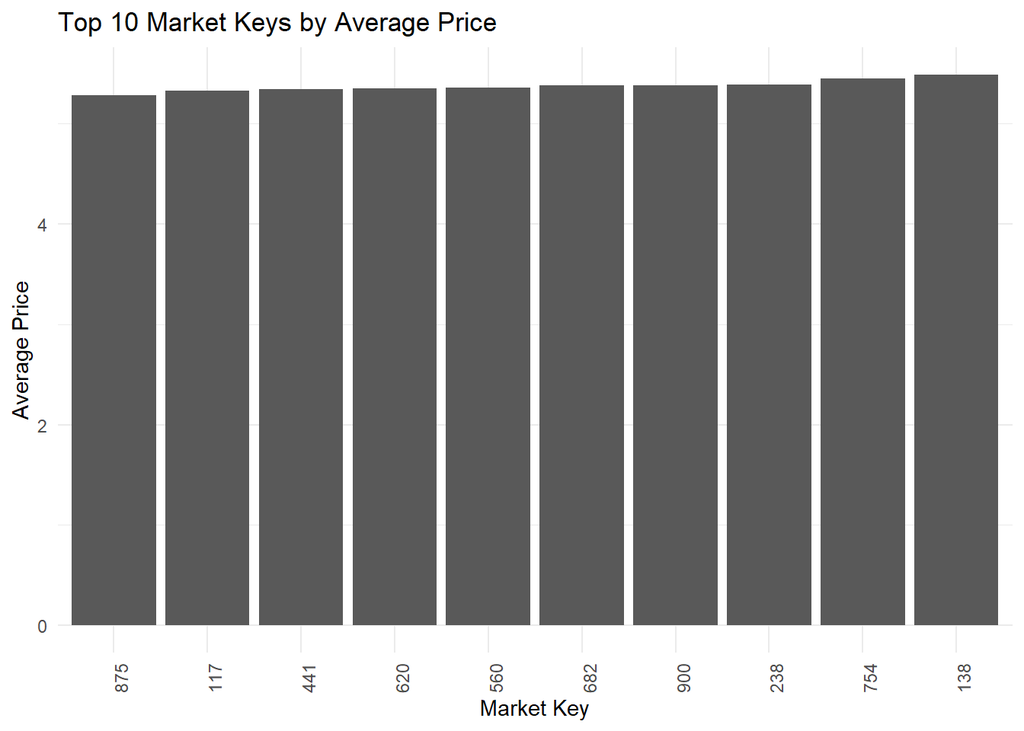

```r
# Create a plot of average price for the top 10 market keys
ggplot(top_avg_price_by_market, aes(x = reorder(MARKET_KEY, Avg_Price), y = Avg_Price)) +
  geom_col() +
  theme_minimal() +
  labs(x = "Market Key", y = "Average Price", title = "Top 10 Market Keys by Average Price") +
  theme(axis.text.x = element_text(angle = 90, hjust = 1))
```

Not much variation in price by market key

## Average Price By Region

```r
avg_price_per_region <- merged_data %>%
  group_by(Region) %>%
  summarise(Total_Dollar_Sales = sum(DOLLAR_SALES, na.rm = TRUE),
            Total_Unit_Sales = sum(UNIT_SALES, na.rm = TRUE),
            Avg_Price = Total_Dollar_Sales / Total_Unit_Sales)

print(avg_price_per_region)
```

```
## # A tibble: 3 × 4
##   Region    Total_Dollar_Sales Total_Unit_Sales Avg_Price
##   <chr>                  <dbl>            <dbl>     <dbl>
## 1 Northern         3348257777.       932898781.      3.59
## 2 Southwest        3567575458.      1076000587.      3.32
## 3 Western          7544295390.      2256463233.      3.34
```

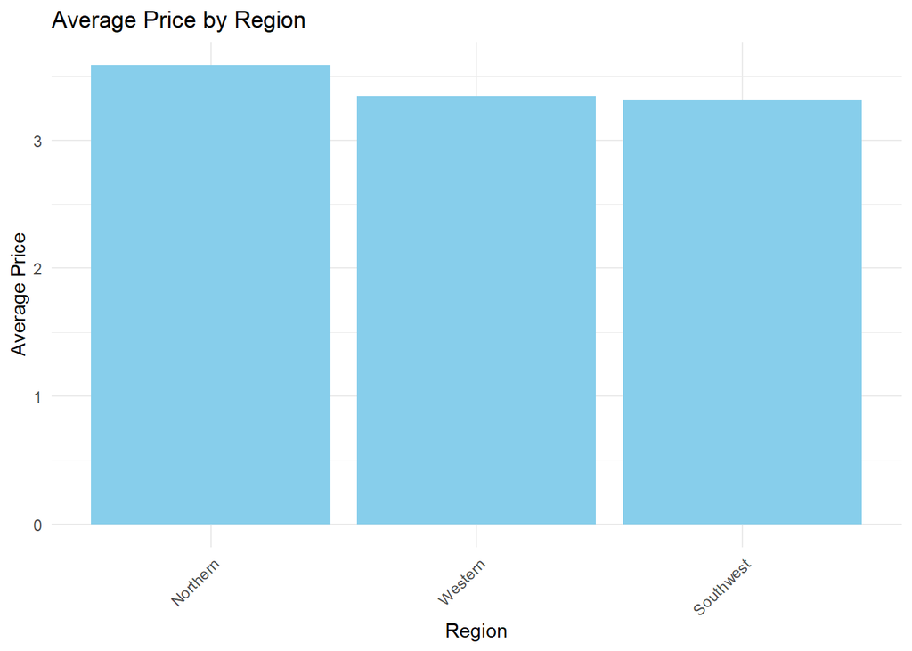

```r
# Plot the average price per region
ggplot(avg_price_per_region, aes(x = reorder(Region, -Avg_Price), y = Avg_Price)) +
  geom_bar(stat = "identity", fill = "skyblue") +
  theme_minimal() +
  labs(x = "Region", y = "Average Price", title = "Average Price by Region") +
  theme(axis.text.x = element_text(angle = 45, hjust = 1))
```

Average price was highest in the Northern region.

## Formatting date for time series graphs

```r
merged_2 <- merged_data

merged_2$DATE <- as.Date(merged_2$DATE, format = "%Y-%m-%d")

str(merged_2)
```

```
## 'data.frame':    24461424 obs. of  12 variables:
##  $ DATE           : Date, format: "2021-08-21" "2022-05-07" ...
##  $ MARKET_KEY     : num  524 637 628 216 210 278 220 499 754 895 ...
##  $ CALORIC_SEGMENT: chr  "DIET/LIGHT" "REGULAR" "DIET/LIGHT" "REGULAR" ...
##  $ CATEGORY       : chr  "SSD" "SSD" "ING ENHANCED WATER" "SSD" ...
##  $ UNIT_SALES     : num  69 4 1 3 4 112 21 3 19 57 ...
##  $ DOLLAR_SALES   : num  389.74 30.96 2.25 7.55 25.96 ...
##  $ MANUFACTURER   : chr  "SWIRE-CC" "COCOS" "JOLLYS" "COCOS" ...
##  $ BRAND          : chr  "DIET YAWN" "GORGEOUS ORANGEOUS" "DIGRESS FLAVORED" "CHERRY FIZZ" ...
##  $ PACKAGE        : chr  "12SMALL 12ONE CUP" "12SMALL 12ONE CUP" "20SMALL MULTI JUG" "1L MULTI JUG" ...
##  $ ITEM           : chr  "YAWN ZERO SUGAR GENTLE DRINK SUPER-JUICE  DURIAN  CUP 12 LIQUID SMALL X12" "GORGEOUS SUNSET OUS GENTLE DRINK AVOCADO  CUP 12 LIQUID SMALL X12" "DIGRESS ZERO NUTRIENT ENHANCED WATER BVRG PURPLE  ZERO CALORIE JUG 20 LIQUID SMALL " "KOOL! RED  GENTLE DRINK RED  COLA CONTOUR…
##  $ AVG_PRICE      : num  5.65 7.74 2.25 2.52 6.49 ...
##  $ Region         : Named chr  "Southwest" "Western" "Western" "Southwest" ...
##   ..- attr(*, "names")= chr [1:24461424] "AZ" "WA" "CA" "AZ" ...
```

## Time series graphs

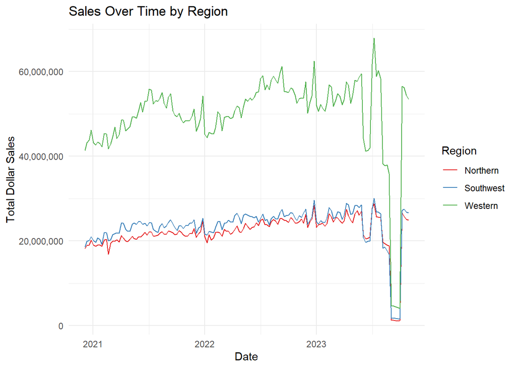

```r
library(scales)
sales_by_region_time <- merged_2 %>%
  group_by(Region, DATE) %>%
  summarise(Total_Dollar_Sales = sum(DOLLAR_SALES, na.rm = TRUE)) %>%
  arrange(Region, DATE)

ggplot(sales_by_region_time, aes(x = DATE, y = Total_Dollar_Sales, group = Region, color = Region)) +
  geom_line() +
  labs(title = "Sales Over Time by Region",
       x = "Date",
       y = "Total Dollar Sales") +
  theme_minimal() +
  scale_color_brewer(palette = "Set1") +
  scale_y_continuous(labels = label_comma())
```

```r
  theme(legend.title = element_blank())
```

```
## List of 1
##  $ legend.title: list()
##   ..- attr(*, "class")= chr [1:2] "element_blank" "element"
##  - attr(*, "class")= chr [1:2] "theme" "gg"
##  - attr(*, "complete")= logi FALSE
##  - attr(*, "validate")= logi TRUE
```

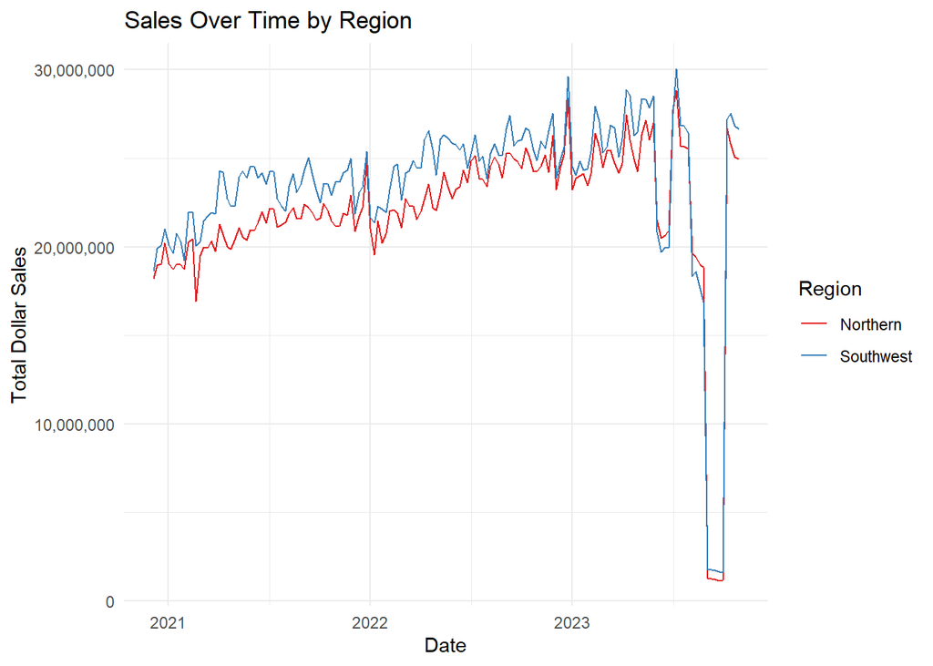

```r
sales_by_region_time <- merged_2 %>%
  filter(Region != "Western") %>%
  group_by(Region, DATE) %>%
  summarise(Total_Dollar_Sales = sum(DOLLAR_SALES, na.rm = TRUE)) %>%
  arrange(Region, DATE)

ggplot(sales_by_region_time, aes(x = DATE, y = Total_Dollar_Sales, group = Region, color = Region)) +
  geom_line() +
  labs(title = "Sales Over Time by Region",
       x = "Date",
       y = "Total Dollar Sales") +
  theme_minimal() +
  scale_color_brewer(palette = "Set1") +
  scale_y_continuous(labels = label_comma())
```

```r
  theme(legend.title = element_blank())
```

```
## List of 1
##  $ legend.title: list()
##   ..- attr(*, "class")= chr [1:2] "element_blank" "element"
##  - attr(*, "class")= chr [1:2] "theme" "gg"
##  - attr(*, "complete")= logi FALSE
##  - attr(*, "validate")= logi TRUE
```

Even though the southwest has almost double the population, the region sales for that area are not proportionally higher than the northern region, suggesting the northern customers may be more valuable. We can further that assessment using the above graph, showing that average price is also higher in the Northern region.

## Caloric Segments by Region

```r
caloric_segment_count <- merged_2 %>%
  group_by(Region, CALORIC_SEGMENT) %>%
  summarise(Count = n(), .groups = 'drop')

# Check the counts
print(caloric_segment_count)
```

```
## # A tibble: 9 × 3
##   Region    CALORIC_SEGMENT   Count
##   <chr>     <chr>             <int>
## 1 Northern  ""                 2001
## 2 Northern  "DIET/LIGHT"     406759
## 3 Northern  "REGULAR"        409021
## 4 Southwest ""                20150
## 5 Southwest "DIET/LIGHT"    4165038
## 6 Southwest "REGULAR"       4262001
## 7 Western   ""                37574
## 8 Western   "DIET/LIGHT"    7598317
## 9 Western   "REGULAR"       7560563
```

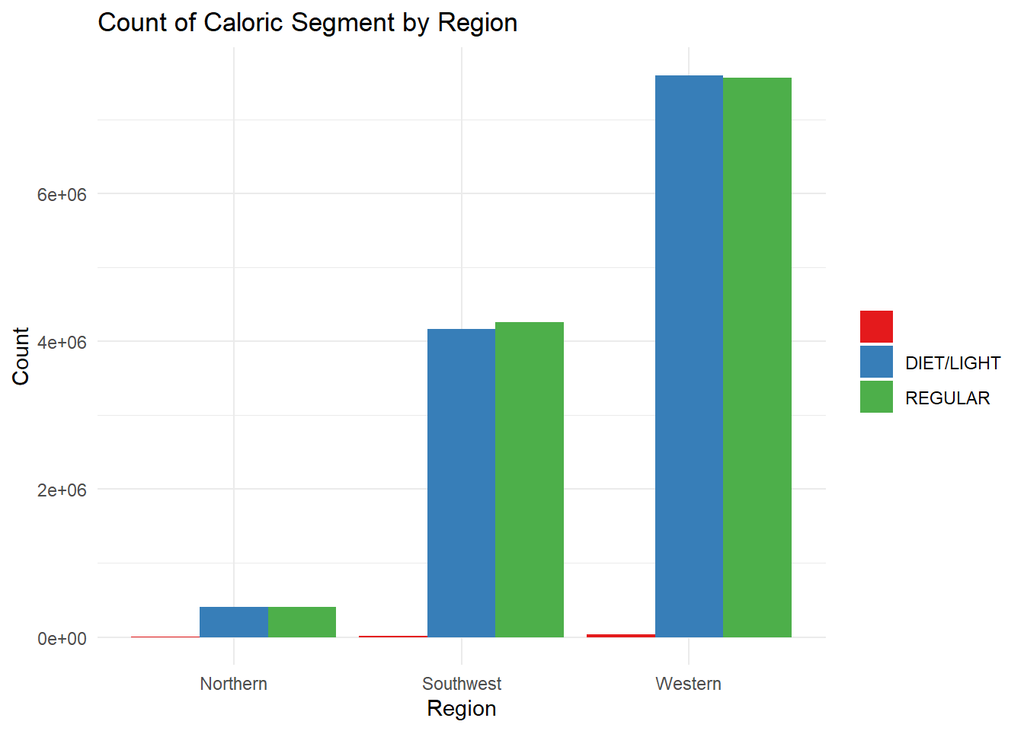

```r
# Create a bar plot for count of Caloric_Segment by Region
ggplot(caloric_segment_count, aes(x = Region, y = Count, fill = CALORIC_SEGMENT)) +
  geom_bar(stat = "identity", position = position_dodge()) +
  labs(title = "Count of Caloric Segment by Region",
       x = "Region",
       y = "Count") +
  scale_fill_brewer(palette = "Set1") +
  theme_minimal() +
  theme(legend.title = element_blank())
```

There wasn’t a large difference in diet verse regular consumption, which we found to be surprising. We believe that regular would be higher than diet by a considerable amount.

## ITEM Variable

```
#Commented out to avoid unnecessary repetition
# necessary files:
  # dollarSales.rda
  # item.rda
  # wordList.csv

#data1 <- data[c("DOLLAR_SALES")]
#save(data1, file='dollarSales.rda')
#a <- data$ITEM
#save(a, file='item.rda')

#d <- data.frame(d = str(""))
#for (ii in 1:length(a)) {
#  tmp <- strsplit(a[ii], split = " ")
#  d[(nrow(d)+1):(nrow(d)+length(tmp[[1]])),1] <- tmp[[1]]
#  d<-distinct(d)
#}
#colnames(d) <- c("d")
#write.csv(d, "wordList.csv")

# intermediate step here
# manually went through wordList and selected likely-important words

# return one-Hot encoding for occurrence of a word in an ITEM description
# done in two parts due to computer memory limits
for (grp in c(1,2)) {
  data1 <- data[c("ITEM")]
  nC <- ncol(data1)
  data1b <- data1 %>% select(-c('ITEM'))

  if (grp==1) {
    idxS <- 1
    idxE <- 87
    filName <- 'oneHot1.rda'
  } else {
    idxS <- 88
    idxE <- 136 #length of d
    filName <- 'oneHot2.rda'
  }
  d <- read.csv('wordList.csv')
```

[output cut: 49 more lines]

```
    data1b<-data1b[,c(1:21,23:28,30:38,40:49)]

    data1$ITEM <- gsub("RAZZBERRY","",data1$ITEM) # to get RAZZ summary
    data1b["RAZZ"] <- 0
    data1b[grep("RAZZ", data1$ITEM),20] <- 1

    data1$ITEM <- gsub("RAZZ","",data1$ITEM) # to get RAZZ summary
    data1b["RAZ"] <- 0
    data1b[grep("RAZ", data1$ITEM),19] <- 1

    data1b<-data1b[,c(1:11,13:15,17:22,24:30,32:46)]
  }
  save(data1b, file=filName)
  rm(data1b)
}
```

The ITEM variable was parsed across the dataset to determine the unique words contained (n=887). After removing numbers, stopwords, and combining similar words (e.g. RED and ROJO), the most likely predictive terms (n=136) were retained for further processing. In a method similar to one-hot encoding, each of the unique reduced word list was added as an integer variable (0 or 1), on a per-row basis to identify if that word occurred in the ITEM variable.

[output not shown]

## Summary

The EDA focusing on the geographical aspects of the dataset gave us insights into the sales and consumer behavior across different regions. Here’s a summary of the key findings:

1. Population Distribution: The Western region has the largest population, followed by the Southwest, with the Northern region having the smallest population among the three. This demographic information sets the stage for understanding the market potential in each region.
2. Price Variation by Market Key: The analysis indicates that there is not much variation in the price of products when segmented by market keys across different regions. This suggests that pricing strategies might be consistent across regions or that market keys do not significantly influence pricing variations.
3. Regional Price Differences: Despite the overall consistency in pricing, the Northern region has the highest average price for products. This could be indicative of different consumer preferences, higher willingness to pay, or a different mix of products being more popular in the Northern region compared to others.
4. Sales vs. Population Size: The sales volume in the Southwest, despite having almost double the population of the Northern region, does not have proportionally higher sales. This suggests that customers in the Northern region might be more valuable.
5. Consumption Patterns of Diet vs. Regular Products: There wasn’t a significant difference in the consumption patterns between diet and regular versions of products. This was surprising, as it was expected that regular variants would greatly outpace diet. This finding could reflect broader consumer trends towards healthier lifestyles or suggest that diet products have gained notable (and possibly changing) acceptance among the population.

The higher average price and relatively strong sales in the Northern region, despite its smaller population, highlight an opportunity to focus on high-value customers and premium product offerings in this area. Meanwhile, the widespread acceptance of both diet and regular products suggests that there is a broad market for various product types, and strategies should not necessarily favor one over the other without further market research. These geographical insights, combined with further analysis of seasonal trends, can help in crafting more more accurate forecasts for Swire.

## Notes & Group Member Contribution

Did not run lines 467 - 653 due to hour long render time.

### Gustav’s part was the code before line 244. Shane’s was 244 - 466. Aiden’s code was 467 - 653. I left Aiden’s comments about his output, as they reflect his analysis of the code I could not run. Louis helped on the writeups, all parts via discussion and was the primary contributor on the previous assignment.